**Project: Investigate the TMDB Movie dataset**

# Introduction

> This project uses the TMDb Movie Dataset that contains more than 10,000 records of movies with details on title, budget, revenue, cast, directors, popularities, etc. The dataset allows to explore a list of questions relating to:
> - The general trends are associated with movies over time?
> - The last question aims to explore the common traits among the profitable films regarding genre, actors, directors, production firms, budget and runtime.

Which genres are most popular from year to year? What kinds of properties are associated with movies that have high revenues?

```python
# Use this cell to set up import statements for all of the packages that you plan to use
import numpy as np
import pandas as pd
import matplotlib.pyplot as plt
import seaborn as sns
%matplotlib inline
```

# Data Wrangling

> In the first section, the data will be loaded, examined and cleaned for the further analysis. Following steps will be carried out:
> 1. Understand the general property: df.info(), df.describe(), df.shape, df.head()
> 2. Drop duplicates
> 3. Drop unncessary columns
> 4. Inspect data types
> 5. Determine cleaning steps

## General Properties

```python
df = pd.read_csv('tmdb-movies.csv')
df.info();
df.describe();
df.head(1);
f'The original dataset contains {df.shape[0]} entries and {df.shape[1]} columns'
```

```
<class 'pandas.core.frame.DataFrame'>
RangeIndex: 10866 entries, 0 to 10865
Data columns (total 21 columns):
 #   Column                Non-Null Count  Dtype
---  ------                --------------  -----
 0   id                    10866 non-null  int64
 1   imdb_id               10856 non-null  object
 2   popularity            10866 non-null  float64
 3   budget                10866 non-null  int64
 4   revenue               10866 non-null  int64
 5   original_title        10866 non-null  object
 6   cast                  10790 non-null  object
 7   homepage              2936 non-null   object
 8   director              10822 non-null  object
 9   tagline               8042 non-null   object
 10  keywords              9373 non-null   object
 11  overview              10862 non-null  object
 12  runtime               10866 non-null  int64
 13  genres                10843 non-null  object
 14  production_companies  9836 non-null   object
 15  release_date          10866 non-null  object
 16  vote_count            10866 non-null  int64
 17  vote_average          10866 non-null  float64
 18  release_year          10866 non-null  int64
 19  budget_adj            10866 non-null  float64
 20  revenue_adj           10866 non-null  float64
dtypes: float64(4), int64(6), object(11)
memory usage: 1.7+ MB
```

```
'The original dataset contains 10866 entries and 21 columns'
```

## Drop duplicates and n/a if necessary

```python
df.duplicated().sum() # remove 1 duplicates
df = df.drop_duplicates()
```

```python
df.isna().sum()
# Missing data in several columns (e.g.cast, director, genres, production-companies), which do not impact on our analysis so no action is required.
```

```
id                         0
imdb_id                   10
popularity                 0
budget                     0
revenue                    0
original_title             0
cast                      76
homepage                7929
director                  44
tagline                 2824
keywords                1493
overview                   4
runtime                    0
genres                    23
production_companies    1030
release_date               0
vote_count                 0
vote_average               0
release_year               0
budget_adj                 0
revenue_adj                0
dtype: int64
```

## Drop unnecessary columns

> - Only keep 13 relevant columns that answer the questions: 'popularity', 'budget', 'revenue', 'original_title', 'cast', 'director', 'runtime', 'genres', 'production_companies', 'release_date','vote_count', 'vote_average'
> - Remove Irrelevant columns: id, imdb_id, budget_adj, revenue_adj, homepage, tagline, keywords and overview.

```python
df.columns
df.drop(['id', 'imdb_id','homepage','tagline', 'keywords',
         'overview','budget_adj', 'revenue_adj' ],
        axis = 1,
        inplace= True)
```

## Inspect data, correct data types and clean data

```python
df.info()
# wrong datatype: release_date => change from object to datetime
```

```
<class 'pandas.core.frame.DataFrame'>
Int64Index: 10865 entries, 0 to 10865
Data columns (total 13 columns):
 #   Column                Non-Null Count  Dtype
---  ------                --------------  -----
 0   popularity            10865 non-null  float64
 1   budget                10865 non-null  int64
 2   revenue               10865 non-null  int64
 3   original_title        10865 non-null  object
 4   cast                  10789 non-null  object
 5   director              10821 non-null  object
 6   runtime               10865 non-null  int64
 7   genres                10842 non-null  object
 8   production_companies  9835 non-null   object
 9   release_date          10865 non-null  object
 10  vote_count            10865 non-null  int64
 11  vote_average          10865 non-null  float64
 12  release_year          10865 non-null  int64
dtypes: float64(2), int64(5), object(6)
memory usage: 1.2+ MB
```

```python
df.describe()
# Zero value in budget, revenue and runtime that needs to be handle.
```

|  | popularity | budget | revenue | runtime | vote_count | vote_average | release_year |
| --- | --- | --- | --- | --- | --- | --- | --- |
| count | 10865.000000 | 1.086500e+04 | 1.086500e+04 | 10865.000000 | 10865.000000 | 10865.000000 | 10865.000000 |
| mean | 0.646446 | 1.462429e+07 | 3.982690e+07 | 102.071790 | 217.399632 | 5.975012 | 2001.321859 |
| std | 1.000231 | 3.091428e+07 | 1.170083e+08 | 31.382701 | 575.644627 | 0.935138 | 12.813260 |
| min | 0.000065 | 0.000000e+00 | 0.000000e+00 | 0.000000 | 10.000000 | 1.500000 | 1960.000000 |
| 25% | 0.207575 | 0.000000e+00 | 0.000000e+00 | 90.000000 | 17.000000 | 5.400000 | 1995.000000 |
| 50% | 0.383831 | 0.000000e+00 | 0.000000e+00 | 99.000000 | 38.000000 | 6.000000 | 2006.000000 |
| 75% | 0.713857 | 1.500000e+07 | 2.400000e+07 | 111.000000 | 146.000000 | 6.600000 | 2011.000000 |
| max | 32.985763 | 4.250000e+08 | 2.781506e+09 | 900.000000 | 9767.000000 | 9.200000 | 2015.000000 |

```python
df['release_date'] = pd.to_datetime(df['release_date'])
```

```python
zero_col = ['budget', 'revenue', 'runtime']
# Replace all 0 values by NaN using numpy
df[zero_col] = df[zero_col].replace(0,np.NAN)
df.dropna(subset = zero_col, inplace=True)
row, col = df.shape
f'There are {row-1} entries and {col} columns'
```

[output not shown]

```python
# Double check the property of clean data.
df.describe();
df.info()
```

```
<class 'pandas.core.frame.DataFrame'>
Int64Index: 3854 entries, 0 to 10848
Data columns (total 13 columns):
 #   Column                Non-Null Count  Dtype
---  ------                --------------  -----
 0   popularity            3854 non-null   float64
 1   budget                3854 non-null   float64
 2   revenue               3854 non-null   float64
 3   original_title        3854 non-null   object
 4   cast                  3850 non-null   object
 5   director              3853 non-null   object
 6   runtime               3854 non-null   float64
 7   genres                3854 non-null   object
 8   production_companies  3808 non-null   object
 9   release_date          3854 non-null   datetime64[ns]
 10  vote_count            3854 non-null   int64
 11  vote_average          3854 non-null   float64
 12  release_year          3854 non-null   int64
dtypes: datetime64[ns](1), float64(5), int64(2), object(5)
memory usage: 421.5+ KB
```

```python
f'After cleaning, the clean dataset has {df.shape[0]} records of movies and {df.shape[1]} columns or properties'
```

```
'After cleaning, the clean dataset has 3854 records of movies and 13 columns or properties'
```

# Exploratory Data Analysis

> After clean data is obtained, it's time to explore data by computing statistics and creating visualizations with the goal of addressing the RQs, looking at one variable at a time, and relationship among variables.

## General trends

It is to explore the movie distribution and the most profitable movie distribution overtime

### How many movies are profitably released yearly with profit over $100 million?

```python
df['profit'] = df['revenue'] - df['budget']
# Create a dataframe for only profitable movies
df_profit = df[df['profit']>100000000]
f'{df_profit.shape[0]} out of {df.shape[0]} movies ({df_profit.shape[0]*100/df.shape[0]:.2f}%) generate a revenue of 100 million dollars or greater'
```

[output not shown]

### What is the distribution of movies and profitable movie over time?

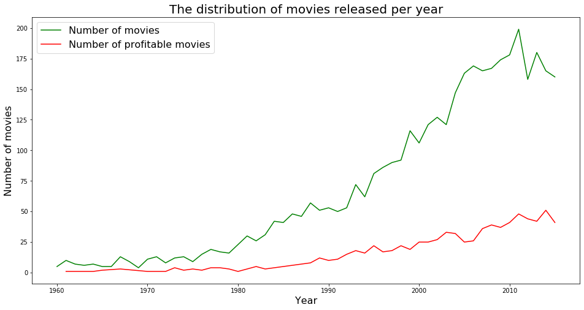

```python
df['release_year'].value_counts().sort_index().plot(figsize=(16,8),color='g',
                                                   label = 'Number of movies');
df_profit['release_year'].value_counts().sort_index().plot(figsize=(16,8), color = 'r',
                                                           label = 'Number of profitable movies')
plt.title('The distribution of movies released per year', fontsize=20)
plt.legend(fontsize=16)
plt.xlabel('Year', fontsize=16)
plt.ylabel('Number of movies',fontsize=16);
```

```python
most_prof_one = df[df['profit']>100000000].sort_values('budget',ascending = False).head(1)
f'The most profitable movie of all time is {most_prof_one.iloc[0,3]}'
```

[output not shown]

### What are the average runtimes of the movie?

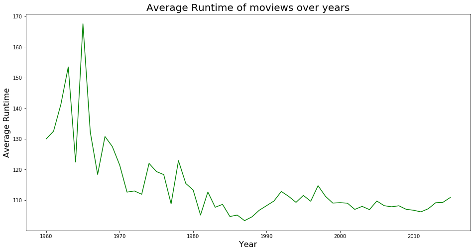

```python
df.groupby('release_year')['runtime'].mean().plot(kind='line',figsize=(16,8),color ='g')
plt.title('Average Runtime of moviews over years', fontsize=20)
plt.xlabel('Year', fontsize=16)
plt.ylabel('Average Runtime', fontsize=16);
```

### What is the total profit trend from year to year?

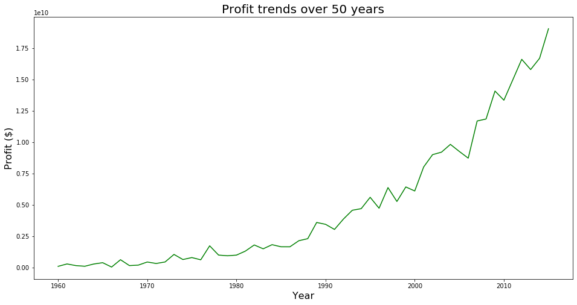

```python
df.groupby('release_year')['profit'].sum().plot(kind = 'line', figsize=(16,8), color = 'g');
plt.title('Profit trends over 50 years', fontsize = 20);
plt.xlabel('Year', fontsize =16 )
plt.ylabel('Profit ($)', fontsize=16);
```

### What is the average popularity in different budget range and revenue range?

```python
df['revenue_range'] = pd.cut(df['revenue'], df['revenue'].describe()[3:8],
                            labels = ['Low', 'Medium', 'High', 'Very High'])
df['revenue_range'].value_counts()
```

```
Very High    964
High         963
Medium       963
Low          962
Name: revenue_range, dtype: int64
```

```python
df['budget_range']=pd.cut(df['budget'], df['budget'].describe()[3:8],
                          labels = ['Low', 'Medium', 'High', 'Very High'])
df['budget_range'].value_counts()
```

```
Low          1045
High         1014
Medium        899
Very High     894
Name: budget_range, dtype: int64
```

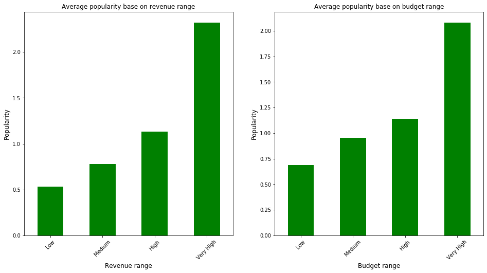

```python
fig, (ax1, ax2) = plt.subplots(1,2)

df.groupby('revenue_range')['popularity'].mean().plot(kind='bar', ax = ax1, color = 'g', figsize=(16,8))
ax1.set_title('Average popularity base on revenue range')
ax1.xaxis.set_label_text('Revenue range', fontsize =12 )
ax1.yaxis.set_label_text('Popularity', fontsize =12 )
ax1.xaxis.set_tick_params(rotation = 45)

df.groupby('budget_range')['popularity'].mean().plot(kind='bar', ax = ax2, color = 'g');
ax2.set_title('Average popularity base on budget range')
ax2.xaxis.set_label_text('Budget range', fontsize =12 )
ax2.yaxis.set_label_text('Popularity', fontsize =12 )
ax2.xaxis.set_tick_params(rotation = 45)
```

### The most expensive and cheapest profitable movies of all time?

```python
most_exp_budget = df[df['profit']>100000000].sort_values('budget',ascending = True).head(5)
cheapest_budget = df[df['profit']>100000000].sort_values('budget',ascending = False).head(5)
print(f'The most expensive profitable movies of all times include: {most_exp_budget.iloc[0:4,3].tolist()}')
f'The cheapest profitable movies of all times include: {cheapest_budget.iloc[0:4,3].tolist()}'
```

[output not shown]

[output not shown]

## Properties of the most profitable movies?

What are the properties associated with the movies making more than 100 million dollars? Properties include: actors, film producers, directors, average budget, average run-time

```python
#function which will take any column as argument from and keep its track
def calculate_count(column):
    data = df_profit[column].str.cat(sep = '|')  # Convert column to string and seperate it by '|'
    data = pd.Series(data.split('|'))      # Storing the values seperately in a Pandas series
    count = data.value_counts(ascending = False)
    return count
```

### Which types of genres are frequently associated with the profitable movies?

```python
genre_count = calculate_count('genres')
f'Genres frequently associated with the successful movies include: {genre_count[:5].index.tolist()}'
```

```
"Genres frequently associated with the successful movies include: ['Action', 'Comedy', 'Adventure', 'Drama', 'Thriller']"
```

### Top actors are frequently associated with the profitable movies?

```python
actors_count = calculate_count('cast')
f'The top five actors have many successful movies include: {actors_count.head(5).index.tolist()}'
```

```
"The top five actors have many successful movies include: ['Tom Cruise', 'Tom Hanks', 'Brad Pitt', 'Adam Sandler', 'Will Smith']"
```

### Top directors are frequently associated with the profitable movies?

```python
director_count = calculate_count('director')
f'The top five directors have many successful movies include: {director_count.head(5).index.tolist()}'
```

```
"The top five directors have many successful movies include: ['Steven Spielberg', 'Robert Zemeckis', 'Michael Bay', 'Quentin Tarantino', 'Clint Eastwood']"
```

### Top production firms are frequently associated with the profitable movies?

```python
prodfirm_count = calculate_count('production_companies')
f'The top five producers have many successful movies include: {prodfirm_count.head(5).index.tolist()}'
```

```
"The top five producers have many successful movies include: ['Warner Bros.', 'Universal Pictures', 'Paramount Pictures', 'Twentieth Century Fox Film Corporation', 'Walt Disney Pictures']"
```

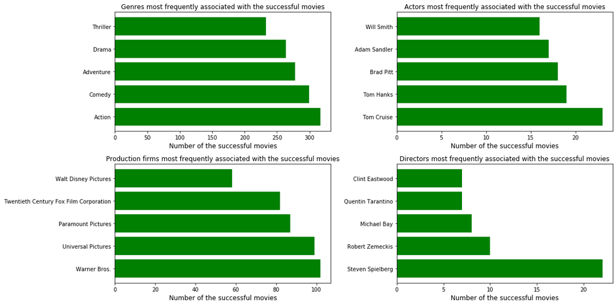

```python
fig = plt.figure(figsize=(16,8))
axes = fig.subplots(nrows=2, ncols=2)
axes[0,0].barh(genre_count.head(5).index, genre_count.head(5), color = 'g')
axes[0,0].set_title('Genres most frequently associated with the successful movies')
axes[0,0].xaxis.set_label_text('Number of the successful movies', fontsize =12 )

axes[0,1].barh(actors_count.head(5).index, actors_count.head(5), color = 'g')
axes[0,1].set_title('Actors most frequently associated with the successful movies')
axes[0,1].xaxis.set_label_text('Number of the successful movies', fontsize =12 )

axes[1,0].barh(prodfirm_count.head(5).index,prodfirm_count.head(5), color = 'g')
axes[1,0].set_title('Production firms most frequently associated with the successful movies')
axes[1,0].xaxis.set_label_text('Number of the successful movies', fontsize =12 )

axes[1,1].barh(director_count.head(5).index, director_count.head(5), color = 'g')
axes[1,1].set_title('Directors most frequently associated with the successful movies')
axes[1,1].xaxis.set_label_text('Number of the successful movies', fontsize =12 );
plt.tight_layout()
```

### What are the average budget, runtime and profits of the profitable movies?

```python
average_budget = df_profit['budget'].mean()
f'The average budget of a successful movie is ${average_budget/1e6:.2f} millions'
```

```
'The average budget of a successful movie is $74.47 millions'
```

```python
average_runtime = df_profit['runtime'].mean()
f'The average runtime of the successful movie is {average_runtime/60:.2f} hour'
```

```
'The average runtime of the successful movie is 1.93 hour'
```

```python
revenue = df_profit['revenue'].mean()
f'The average revenue of the successful movie is ${revenue/1e6:.2f} millions'
```

```
'The average revenue of the successful movie is $345.33 millions'
```

> **Limitations**
> - Only consider movies making a profit of 100 million dollars or over.
> - Rows with NaN were droped so some key data might be lost
> - These factors should only be taken into consideration but it does not 100% guarantee that success of a movie.